# The Term Deposit Subscription

## 1.Understand the data

```python
import pandas as pd
import numpy as np
import matplotlib.pyplot as plt
import seaborn as sns
from sklearn import preprocessing, model_selection, linear_model, ensemble, neighbors, metrics,feature_selection

#import warnings
#warnings.filterwarnings('ignore')
```

```python
bank = pd.read_csv('./bank-full.csv', sep = ';')
#bank = pd.read_csv('./bank-additional-full.csv', sep = ';')
#bank = bank.drop(columns=['emp.var.rate', 'cons.price.idx', 'cons.conf.idx', 'euribor3m', 'nr.employed', 'duration', 'age'])
```

```python
print(bank.head())
print(bank.info())
print(bank.isnull().sum()) # check missing values
```

```
   age           job  marital  education default  balance housing loan  \
0   58    management  married   tertiary      no     2143     yes   no
1   44    technician   single  secondary      no       29     yes   no
2   33  entrepreneur  married  secondary      no        2     yes  yes
3   47   blue-collar  married    unknown      no     1506     yes   no
4   33       unknown   single    unknown      no        1      no   no

   contact  day month  duration  campaign  pdays  previous poutcome   y
0  unknown    5   may       261         1     -1         0  unknown  no
1  unknown    5   may       151         1     -1         0  unknown  no
2  unknown    5   may        76         1     -1         0  unknown  no
3  unknown    5   may        92         1     -1         0  unknown  no
4  unknown    5   may       198         1     -1         0  unknown  no
<class 'pandas.core.frame.DataFrame'>
RangeIndex: 45211 entries, 0 to 45210
Data columns (total 17 columns):
 #   Column     Non-Null Count  Dtype
---  ------     --------------  -----
 0   age        45211 non-null  int64
 1   job        45211 non-null  object
 2   marital    45211 non-null  object
 3   education  45211 non-null  object
 4   default    45211 non-null  object
 5   balance    45211 non-null  int64
 6   housing    45211 non-null  object
 7   loan       45211 non-null  object
 8   contact    45211 non-null  object
 9   day        45211 non-null  int64
 10  month      45211 non-null  object
 11  duration   45211 non-null  int64
 12  campaign   45211 non-null  int64
 13  pdays      45211 non-null  int64
 14  previous   45211 non-null  int64
 15  poutcome   45211 non-null  object
 16  y          45211 non-null  object
dtypes: int64(7), object(10)
memory usage: 5.9+ MB
None
age          0
job          0
marital      0
education    0
default      0
balance      0
housing      0
loan         0
contact      0
day          0
month        0
duration     0
campaign     0
pdays        0
previous     0
poutcome     0
y            0
dtype: int64
```

Input variables:

##### bank client data:

1 - age (numeric) \ 2 - job : type of job (categorical: "admin.","unknown","unemployed","management","housemaid","entrepreneur","student", "blue-collar","self-employed","retired","technician","services") \ 3 - marital : marital status (categorical: "married","divorced","single"; note: "divorced" means divorced or widowed)\ 4 - education (categorical: "unknown","secondary","primary","tertiary")\ 5 - default: has credit in default? (binary: "yes","no")\ 6 - balance: average yearly balance, in euros (numeric) \ 7 - housing: has housing loan? (binary: "yes","no")\ 8 - loan: has personal loan? (binary: "yes","no")

###### related with the last contact of the current campaign:

9 - contact: contact communication type (categorical: "unknown","telephone","cellular") \ 10 - day: last contact day of the month (numeric)\ 11 - month: last contact month of year (categorical: "jan", "feb", "mar", ..., "nov", "dec")\ 12 - duration: last contact duration, in seconds (numeric)\

##### other attributes:

13 - campaign: number of contacts performed during this campaign and for this client (numeric, includes last contact)\ 14 - pdays: number of days that passed by after the client was last contacted from a previous campaign (numeric, -1 means client was not previously contacted)\ 15 - previous: number of contacts performed before this campaign and for this client (numeric)\ 16 - poutcome: outcome of the previous marketing campaign (categorical: "unknown","other","failure","success")\

##### Output variable (desired target):

17 - y - has the client subscribed a term deposit? (binary: "yes","no")

#### Continuous Variables

'age', 'balance', 'day', 'duration', 'campaign', 'pdays', 'previous'

#### Categorical Variables:

'job', 'marital', 'education', 'default', 'housing', 'loan','contact','month', 'poutcome', 'y'

```python
bank["pdays"]=[999 if each==-1  else each for each in bank.pdays]
```

```
numerical columns:  Index(['age', 'balance', 'day', 'duration', 'campaign', 'pdays', 'previous'], dtype='object')
```

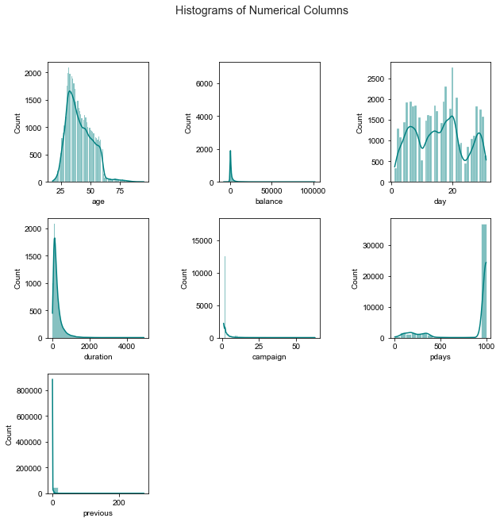

```
categorical columns columns:  Index(['job', 'marital', 'education', 'default', 'housing', 'loan', 'contact',
       'month', 'poutcome', 'y'],
      dtype='object')
```

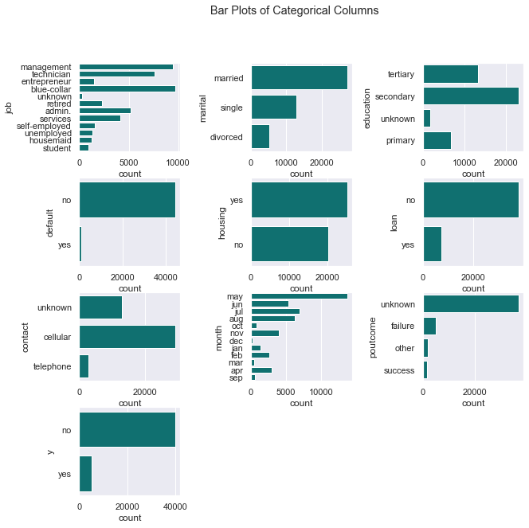

```python
numerical_columns = bank.describe().columns
print('numerical columns: ', numerical_columns)
fig, axes = plt.subplots(3, 3, figsize=(10, 10))
plt.subplots_adjust(wspace=0.7, hspace=0.3)
sns.set(style="darkgrid")
for i, ax in enumerate(axes.ravel()):
    if i > 6:
        ax.set_visible(False)
        continue
    sns.histplot(data=bank, x=numerical_columns[i],ax = ax, kde=True, color = 'teal')
fig.suptitle('Histograms of Numerical Columns')
plt.show()

categorical_columns = bank.describe(include=[object]).columns
print('categorical columns columns: ', categorical_columns)

fig, axes = plt.subplots(4, 3, figsize=(10, 10))
plt.subplots_adjust(wspace=0.7, hspace=0.3)
sns.set(style="darkgrid")
for i, ax in enumerate(axes.ravel()):
    if i > 9:
        ax.set_visible(False)
        continue
    sns.countplot(y = categorical_columns[i], data=bank, ax=ax, color = 'teal')
fig.suptitle('Bar Plots of Categorical Columns')
plt.show()
```

```python
bank.y.value_counts(normalize=True)
# 88% of records didn't respond to the campaign.
# Imbalanced data

#understand the categorical variables

print('Jobs:\n', bank['job'].unique())
print('Marital:\n', bank['marital'].unique())
print('Education:\n', bank['education'].unique())
print('Default:\n', bank['default'].unique())
print('Housing:\n', bank['housing'].unique())
print('Loan:\n', bank['loan'].unique())

print(bank.pdays.value_counts(normalize=True))
# 82% of the records has the value -1 in pdays.
# Since 82% of the customers were not previously contacted, 'pdays' that shows the number of days passed since the last contact gives no much information
```

```
Jobs:
 ['management' 'technician' 'entrepreneur' 'blue-collar' 'unknown'
 'retired' 'admin.' 'services' 'self-employed' 'unemployed' 'housemaid'
 'student']
Marital:
 ['married' 'single' 'divorced']
Education:
 ['tertiary' 'secondary' 'unknown' 'primary']
Default:
 ['no' 'yes']
Housing:
 ['yes' 'no']
Loan:
 ['no' 'yes']
999    0.817367
182    0.003694
92     0.003251
91     0.002787
183    0.002787
         ...
449    0.000022
452    0.000022
648    0.000022
595    0.000022
530    0.000022
Name: pdays, Length: 559, dtype: float64
```

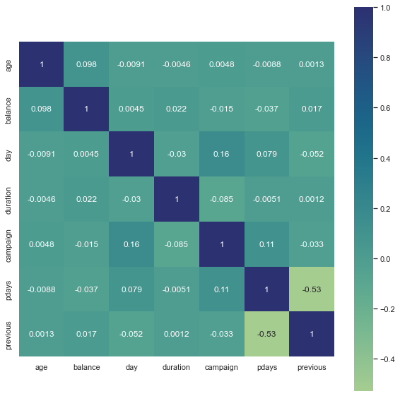

```python
plt.figure(figsize=(10,10))

sns.heatmap(bank.corr(method="pearson"),square=True,annot=True, cmap ='crest')
```

```python
bank_new = bank.copy()
#bank_new = bank_new.drop(['duration', 'pdays' ], axis = 1)
```

## 2. Pre-processing

### One-Hot Encoding

```python
# One-Hot Encoding
categorical_columns = bank_new.describe(include=[object]).columns

bank_new = pd.concat([bank_new, pd.get_dummies(bank_new[categorical_columns])], axis=1)
bank_new = bank_new.drop(categorical_columns, axis =1)
print(bank_new.info())
```

```
<class 'pandas.core.frame.DataFrame'>
RangeIndex: 45211 entries, 0 to 45210
Data columns (total 53 columns):
 #   Column               Non-Null Count  Dtype
---  ------               --------------  -----
 0   age                  45211 non-null  int64
 1   balance              45211 non-null  int64
 2   day                  45211 non-null  int64
 3   duration             45211 non-null  int64
 4   campaign             45211 non-null  int64
 5   pdays                45211 non-null  int64
 6   previous             45211 non-null  int64
 7   job_admin.           45211 non-null  uint8
 8   job_blue-collar      45211 non-null  uint8
 9   job_entrepreneur     45211 non-null  uint8
```

[output cut: 46 more lines]

```python
# Normalizing Numerical variables

min_max_scaler=preprocessing.MinMaxScaler()
data_scaled=pd.DataFrame(min_max_scaler.fit_transform(bank_new),columns=bank_new.columns)
```

```python
# Store the campaign results and drop it from the dataset

y = data_scaled.y_yes
data_scaled = data_scaled.drop(['y_yes','y_no'], axis = 1)

# Store the campaign results and drop it from the dataset

#y = bank_new.y_yes
#data_scaled = data_scaled.drop(['y_yes','y_no'], axis = 1)
#s = preprocessing.StandardScaler()
```

```python
data_scaled
```

|  | age | balance | day | duration | campaign | pdays | previous | job_admin. | job_blue-collar | job_entrepreneur | ... | month_jun | month_mar | month_may | month_nov | month_oct | month_sep | poutcome_failure | poutcome_other | poutcome_success | poutcome_unknown |
| --- | --- | --- | --- | --- | --- | --- | --- | --- | --- | --- | --- | --- | --- | --- | --- | --- | --- | --- | --- | --- | --- |
| 0 | 0.519481 | 0.092259 | 0.133333 | 0.053070 | 0.000000 | 1.000000 | 0.000000 | 0.0 | 0.0 | 0.0 | ... | 0.0 | 0.0 | 1.0 | 0.0 | 0.0 | 0.0 | 0.0 | 0.0 | 0.0 | 1.0 |
| 1 | 0.337662 | 0.073067 | 0.133333 | 0.030704 | 0.000000 | 1.000000 | 0.000000 | 0.0 | 0.0 | 0.0 | ... | 0.0 | 0.0 | 1.0 | 0.0 | 0.0 | 0.0 | 0.0 | 0.0 | 0.0 | 1.0 |
| 2 | 0.194805 | 0.072822 | 0.133333 | 0.015453 | 0.000000 | 1.000000 | 0.000000 | 0.0 | 0.0 | 1.0 | ... | 0.0 | 0.0 | 1.0 | 0.0 | 0.0 | 0.0 | 0.0 | 0.0 | 0.0 | 1.0 |
| 3 | 0.376623 | 0.086476 | 0.133333 | 0.018707 | 0.000000 | 1.000000 | 0.000000 | 0.0 | 1.0 | 0.0 | ... | 0.0 | 0.0 | 1.0 | 0.0 | 0.0 | 0.0 | 0.0 | 0.0 | 0.0 | 1.0 |
| 4 | 0.194805 | 0.072812 | 0.133333 | 0.040260 | 0.000000 | 1.000000 | 0.000000 | 0.0 | 0.0 | 0.0 | ... | 0.0 | 0.0 | 1.0 | 0.0 | 0.0 | 0.0 | 0.0 | 0.0 | 0.0 | 1.0 |
| ... | ... | ... | ... | ... | ... | ... | ... | ... | ... | ... | ... | ... | ... | ... | ... | ... | ... | ... | ... | ... | ... |
| 45206 | 0.428571 | 0.080293 | 0.533333 | 0.198658 | 0.032258 | 1.000000 | 0.000000 | 0.0 | 0.0 | 0.0 | ... | 0.0 | 0.0 | 0.0 | 1.0 | 0.0 | 0.0 | 0.0 | 0.0 | 0.0 | 1.0 |
| 45207 | 0.688312 | 0.088501 | 0.533333 | 0.092721 | 0.016129 | 1.000000 | 0.000000 | 0.0 | 0.0 | 0.0 | ... | 0.0 | 0.0 | 0.0 | 1.0 | 0.0 | 0.0 | 0.0 | 0.0 | 0.0 | 1.0 |
| 45208 | 0.701299 | 0.124689 | 0.533333 | 0.229158 | 0.064516 | 0.183367 | 0.010909 | 0.0 | 0.0 | 0.0 | ... | 0.0 | 0.0 | 0.0 | 1.0 | 0.0 | 0.0 | 0.0 | 0.0 | 1.0 | 0.0 |
| 45209 | 0.506494 | 0.078868 | 0.533333 | 0.103294 | 0.048387 | 1.000000 | 0.000000 | 0.0 | 1.0 | 0.0 | ... | 0.0 | 0.0 | 0.0 | 1.0 | 0.0 | 0.0 | 0.0 | 0.0 | 0.0 | 1.0 |
| 45210 | 0.246753 | 0.099777 | 0.533333 | 0.073404 | 0.016129 | 0.187375 | 0.040000 | 0.0 | 0.0 | 1.0 | ... | 0.0 | 0.0 | 0.0 | 1.0 | 0.0 | 0.0 | 0.0 | 1.0 | 0.0 | 0.0 |

45211 rows × 51 columns

## Splitting data in to train, test set (80%, 20%)

```python
from sklearn.model_selection import train_test_split
X_train, X_test, y_train, y_test = train_test_split(data_scaled, y, test_size=0.2, random_state=50, stratify = y)
```

## Handling Imbalanced Data: Upsampling

```python
# Upsampling
# Since 88% of records didn't respond to the campaign, we're going to use upsampling method to balance data

from imblearn.over_sampling import SMOTE

sm = SMOTE(random_state=12)
X_balanced, y_balanced = sm.fit_resample(X_train, y_train)
print('X_train shape: ', X_balanced.shape, '', 'y_train shape: ', y_balanced.shape)
print(y_balanced.value_counts())

#X_train = s.fit_transform(X_train)
```

```
X_train shape:  (63874, 51)  y_train shape:  (63874,)
0.0    31937
1.0    31937
Name: y_yes, dtype: int64
```

## 3. Model Building

### Logistic Regression

```
Logistic Regression

Classification Report

              precision    recall  f1-score   support

         0.0       0.97      0.86      0.91      7985
         1.0       0.43      0.80      0.56      1058

    accuracy                           0.85      9043
   macro avg       0.70      0.83      0.74      9043
weighted avg       0.91      0.85      0.87      9043

Confusion Matrix
```

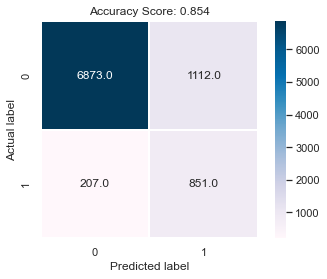

```
Train Accuracy (mean): % 85.08786338954192
std: % 0.7778850415575609
MAE (mean absolute error): % -0.14912136610458057
Mean Absolute Error (MAE): 0.15
Mean Squared Error (MSE): 0.15
Root Mean Squared Error (RMSE): 0.38
Cohen Score 0.48510180898541966
Matthew Score 0.5185394301919152
```

```python
from sklearn.metrics import classification_report
from sklearn.linear_model import LogisticRegression

lr = LogisticRegression(random_state = 42, max_iter=400)
lr.fit(X_balanced,y_balanced)
y_pred = lr.predict(X_test)
print("Logistic Regression","\n")
print("Classification Report","\n")
print(classification_report(y_test, y_pred))


# Confusion Matrix
from sklearn.metrics import accuracy_score
from sklearn.metrics import confusion_matrix

print("Confusion Matrix","\n")
score = round(accuracy_score(y_test, y_pred),3)
cm1 = confusion_matrix(y_test, y_pred)
sns.heatmap(cm1, annot=True, fmt=".1f", linewidths=.3,
        square = True, cmap = 'PuBu')
plt.ylabel('Actual label')
plt.xlabel('Predicted label')
plt.title('Accuracy Score: {0}'.format(score), size = 12)
plt.show()
print("\n")

# Cross Validation
from sklearn.model_selection import cross_val_score

accuracies_lr = cross_val_score(estimator = lr, X = X_balanced, y = y_balanced, cv = 10)
print("Train Accuracy (mean): %",accuracies_lr.mean()*100)
print("std: %",accuracies_lr.std()*100)

scores_lr = cross_val_score(lr, X_balanced, y_balanced, scoring='neg_mean_absolute_error', cv=10,)
print ("MAE (mean absolute error): %" , scores_lr.mean())


# Errors
from sklearn.metrics import mean_absolute_error, mean_squared_error

mae_lr = mean_absolute_error(lr.predict(X_test), y_test)
mse_lr = mean_squared_error(lr.predict(X_test), y_test)
rmse_lr = np.sqrt(mse_lr)
print('Mean Absolute Error (MAE): %.2f' % mae_lr)
print('Mean Squared Error (MSE): %.2f' % mse_lr)
print('Root Mean Squared Error (RMSE): %.2f' % rmse_lr)


# Cohen - Matthew Score
from sklearn.metrics import cohen_kappa_score, matthews_corrcoef

print("Cohen Score",cohen_kappa_score(y_test, y_pred))
print("Matthew Score",matthews_corrcoef(y_test, y_pred))

recall_lr = metrics.recall_score(y_test, y_pred)
precision_lr = metrics.precision_score(y_test, y_pred)
accuracy_lr = score
```

```python
recall_lr
```

```
0.8043478260869565
```

### K Nearest Neighbors

```
KNN Algorithm
Classification Report
              precision    recall  f1-score   support

         0.0       0.95      0.81      0.87      7985
         1.0       0.32      0.66      0.43      1058

    accuracy                           0.79      9043
   macro avg       0.63      0.74      0.65      9043
weighted avg       0.87      0.79      0.82      9043

Confusion Matrix
```

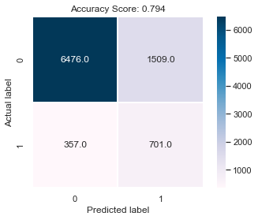

```
Train Accuracy (mean): % 83.83067334350388
std: % 0.3613273231671725
MAE (mean): % -0.1616932665649612


Mean Absolute Error (MAE): 0.21
Mean Squared Error (MSE): 0.21
Root Mean Squared Error (RMSE): 0.45


Cohen Score 0.3216704151009778
Matthew Score 0.35422759770454
```

```python
from sklearn.neighbors import KNeighborsClassifier

classifier = KNeighborsClassifier(n_neighbors=100,weights="distance")
classifier.fit(X_balanced, y_balanced)
y_pred = classifier.predict(X_test)

print("KNN Algorithm")
print("Classification Report")
print(classification_report(y_test, y_pred))


print("Confusion Matrix","\n")
score = round(accuracy_score(y_test, y_pred),3)
cm1 = confusion_matrix(y_test, y_pred)
sns.heatmap(cm1, annot=True, fmt=".1f", linewidths=.3,
        square = True, cmap = 'PuBu')
plt.ylabel('Actual label')
plt.xlabel('Predicted label')
plt.title('Accuracy Score: {0}'.format(score), size = 12)
plt.show()
print("\n")

accuracies_knn = cross_val_score(estimator = classifier, X = X_balanced, y = y_balanced, cv = 10)
print("Train Accuracy (mean): %",accuracies_knn.mean()*100)
print("std: %",accuracies_knn.std()*100)

scores_knn = cross_val_score(classifier, X_balanced, y_balanced, scoring='neg_mean_absolute_error', cv=10,)
print ("MAE (mean): %" , scores_knn.mean())
print("\n")

mae_knn = mean_absolute_error(classifier.predict(X_test), y_test)
mse_knn = mean_squared_error(classifier.predict(X_test), y_test)
rmse_knn = np.sqrt(mse_knn)
print('Mean Absolute Error (MAE): %.2f' % mae_knn)
print('Mean Squared Error (MSE): %.2f' % mse_knn)
print('Root Mean Squared Error (RMSE): %.2f' % rmse_knn)
print("\n")

print("Cohen Score",cohen_kappa_score(y_test, y_pred))
print("Matthew Score",matthews_corrcoef(y_test, y_pred))

recall_knn = metrics.recall_score(y_test, y_pred)
precision_knn = metrics.precision_score(y_test, y_pred)
accuracy_knn = score
```

```python
recall_knn
```

```
0.6625708884688091
```

### Random Forest

```
Random Forest Algorithm

Classification Report

              precision    recall  f1-score   support

         0.0       0.97      0.83      0.89      7985
         1.0       0.39      0.80      0.52      1058

    accuracy                           0.83      9043
   macro avg       0.68      0.82      0.71      9043
weighted avg       0.90      0.83      0.85      9043

Confusion Matrix
```

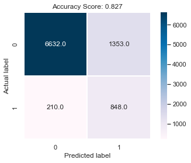

```
Train Accuracy (mean): % 85.46675434280202
std: % 1.8128087377733078
MAE (mean): % -0.14533245657197977


Mean Absolute Error (MAE): 0.17
Mean Squared Error (MSE): 0.17
Root Mean Squared Error (RMSE): 0.42


Cohen Score 0.43038966066532036
Matthew Score 0.47341675985200193
```

```python
from sklearn.ensemble import RandomForestClassifier

rf = RandomForestClassifier(n_estimators=10 ,n_jobs=-1,
                            random_state=42,
                            max_depth= 5
                           # class_weight="balanced",
                            #max_features=10)
                            )

rf.fit(X_balanced, y_balanced)
rf_predict = rf.predict(X_test)
print("Random Forest Algorithm","\n")
print("Classification Report","\n")
print(classification_report(y_test, rf_predict))

print("Confusion Matrix","\n")
score = round(accuracy_score(y_test, rf_predict),3)
cm1 = confusion_matrix(y_test, rf_predict)
sns.heatmap(cm1, annot=True, fmt=".1f", linewidths=.3,
            square = True, cmap = 'PuBu')
plt.ylabel('Actual label')
plt.xlabel('Predicted label')
plt.title('Accuracy Score: {0}'.format(score), size = 12)
plt.show()
print("\n")

accuracies_rf = cross_val_score(estimator = rf, X = X_balanced, y = y_balanced, cv = 10)
print("Train Accuracy (mean): %",accuracies_rf.mean()*100)
print("std: %",accuracies_rf.std()*100)

scores_rf = cross_val_score(rf, X_balanced, y_balanced, scoring='neg_mean_absolute_error', cv=10,)
print ("MAE (mean): %" , scores_rf.mean())
print("\n")

mae_rf = mean_absolute_error(rf.predict(X_test), y_test)
mse_rf = mean_squared_error(rf.predict(X_test), y_test)
rmse_rf = np.sqrt(mse_rf)
print('Mean Absolute Error (MAE): %.2f' % mae_rf)
print('Mean Squared Error (MSE): %.2f' % mse_rf)
print('Root Mean Squared Error (RMSE): %.2f' % rmse_rf)
print("\n")

print("Cohen Score",cohen_kappa_score(y_test, rf_predict))
print("Matthew Score",matthews_corrcoef(y_test, rf_predict))
print("\n")

recall_rf = metrics.recall_score(y_test, y_pred)
precision_rf = metrics.precision_score(y_test, y_pred)
accuracy_rf = score
```

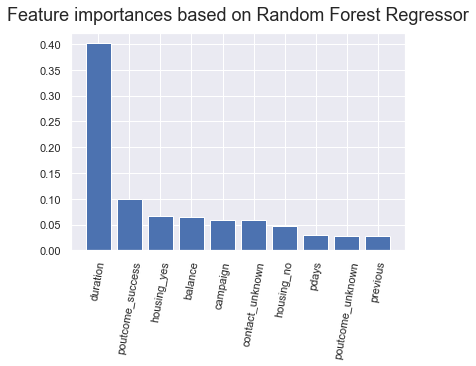

```python
ranking = rf.feature_importances_
features = np.argsort(ranking)[::-1][:10]
columns = data_scaled.columns
plt.title("Feature importances based on Random Forest Regressor", y = 1.03, size = 18)
plt.bar(range(len(features)), ranking[features], align="center")
plt.xticks(range(len(features)), columns[features], rotation=80)
plt.show()
```

### Decision Tree

```
Decision Tree Algorithm
Classification Report
              precision    recall  f1-score   support

         0.0       0.94      0.91      0.93      7985
         1.0       0.45      0.54      0.49      1058

    accuracy                           0.87      9043
   macro avg       0.70      0.73      0.71      9043
weighted avg       0.88      0.87      0.87      9043

Confusion Matrix
```

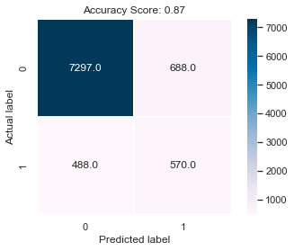

```
Train Accuracy (mean): % 90.6677476919451
std: % 4.7215690113804225
MAE (mean): % -0.09150649571045759


Mean Absolute Error (MAE): 0.13
Mean Squared Error (MSE): 0.13
Root Mean Squared Error (RMSE): 0.36


Cohen Score 0.41829308717042113
Matthew Score 0.4203551730097237
```

```python
from sklearn.tree import DecisionTreeClassifier

dt=DecisionTreeClassifier(criterion='entropy')
dt.fit(X_balanced, y_balanced)

y_pred = dt.predict(X_test)

print("Decision Tree Algorithm")
print("Classification Report")
print(classification_report(y_test, y_pred))

print("Confusion Matrix","\n")
score = round(accuracy_score(y_test, y_pred),3)
cm1 = confusion_matrix(y_test, y_pred)
sns.heatmap(cm1, annot=True, fmt=".1f", linewidths=.3,
        square = True, cmap = 'PuBu')
plt.ylabel('Actual label')
plt.xlabel('Predicted label')
plt.title('Accuracy Score: {0}'.format(score), size = 12)
plt.show()
print("\n")

accuracies_dt = cross_val_score(estimator = dt, X = X_balanced, y = y_balanced, cv = 10)
print("Train Accuracy (mean): %",accuracies_dt.mean()*100)
print("std: %",accuracies_dt.std()*100)

scores_dt = cross_val_score(dt, X_balanced, y_balanced, scoring='neg_mean_absolute_error', cv=10,)
print ("MAE (mean): %" , scores_dt.mean())
print("\n")

mae_dt = mean_absolute_error(dt.predict(X_test), y_test)
mse_dt = mean_squared_error(dt.predict(X_test), y_test)
rmse_dt = np.sqrt(mse_dt)
print('Mean Absolute Error (MAE): %.2f' % mae_dt)
print('Mean Squared Error (MSE): %.2f' % mse_dt)
print('Root Mean Squared Error (RMSE): %.2f' % rmse_dt)
print("\n")

print("Cohen Score",cohen_kappa_score(y_test, y_pred))
print("Matthew Score",matthews_corrcoef(y_test, y_pred))

recall_dt = metrics.recall_score(y_test, y_pred)
precision_dt = metrics.precision_score(y_test, y_pred)
accuracy_dt = score
```

```python
recall_dt
```

```
0.5387523629489603
```

### SVC

```python
from sklearn.svm import SVC
svc= SVC(kernel = 'sigmoid')
svc.fit(X_balanced, y_balanced)

y_pred = svc.predict(X_test)
```

```
Decision Tree Algorithm
Classification Report
              precision    recall  f1-score   support

         0.0       0.92      0.59      0.72      7985
         1.0       0.16      0.59      0.25      1058

    accuracy                           0.59      9043
   macro avg       0.54      0.59      0.48      9043
weighted avg       0.83      0.59      0.66      9043

Confusion Matrix
```

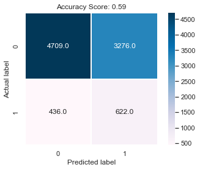

```
Mean Absolute Error (MAE): 0.41
Mean Squared Error (MSE): 0.41
Root Mean Squared Error (RMSE): 0.64


Cohen Score 0.08207303793875342
Matthew Score 0.11528929524391028
```

```python
print("Decision Tree Algorithm")
print("Classification Report")
print(classification_report(y_test, y_pred))

print("Confusion Matrix","\n")
score = round(accuracy_score(y_test, y_pred),3)
cm1 = confusion_matrix(y_test, y_pred)
sns.heatmap(cm1, annot=True, fmt=".1f", linewidths=.3,
        square = True, cmap = 'PuBu')
plt.ylabel('Actual label')
plt.xlabel('Predicted label')
plt.title('Accuracy Score: {0}'.format(score), size = 12)
plt.show()
print("\n")

mae_svc = mean_absolute_error(svc.predict(X_test), y_test)
mse_svc = mean_squared_error(svc.predict(X_test), y_test)
rmse_svc = np.sqrt(mse_svc)
print('Mean Absolute Error (MAE): %.2f' % mae_svc)
print('Mean Squared Error (MSE): %.2f' % mse_svc)
print('Root Mean Squared Error (RMSE): %.2f' % rmse_svc)
print("\n")

print("Cohen Score",cohen_kappa_score(y_test, y_pred))
print("Matthew Score",matthews_corrcoef(y_test, y_pred))

recall_svc = metrics.recall_score(y_test, y_pred)
precision_svc = metrics.precision_score(y_test, y_pred)
accuracy_svc = score
```

### Gaussian Naïve Bayes

```
Decision Tree Algorithm
Classification Report
              precision    recall  f1-score   support

         0.0       0.95      0.82      0.88      7985
         1.0       0.32      0.65      0.43      1058

    accuracy                           0.80      9043
   macro avg       0.63      0.73      0.65      9043
weighted avg       0.87      0.80      0.82      9043

Confusion Matrix
```

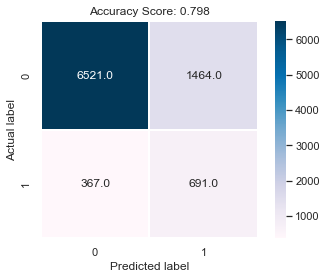

```
Accuracy (mean): % 73.9111463201268
std: % 0.5995837682863621
MAE (mean): % -0.2608885367987318


Mean Absolute Error (MAE): 0.20
Mean Squared Error (MSE): 0.20
Root Mean Squared Error (RMSE): 0.45


Cohen Score 0.3240411511179404
Matthew Score 0.3544053648929509
```

```python
from sklearn.naive_bayes import GaussianNB
gaussiannb= GaussianNB()
gaussiannb.fit(X_balanced, y_balanced)

y_pred = gaussiannb.predict(X_test)

print("Decision Tree Algorithm")
print("Classification Report")
print(classification_report(y_test, y_pred))

print("Confusion Matrix","\n")
score = round(accuracy_score(y_test, y_pred),3)
cm1 = confusion_matrix(y_test, y_pred)
sns.heatmap(cm1, annot=True, fmt=".1f", linewidths=.3,
        square = True, cmap = 'PuBu')
plt.ylabel('Actual label')
plt.xlabel('Predicted label')
plt.title('Accuracy Score: {0}'.format(score), size = 12)
plt.show()
print("\n")

accuracies_gnb = cross_val_score(estimator = gaussiannb, X = X_balanced, y = y_balanced, cv = 10)
print("Accuracy (mean): %",accuracies_gnb.mean()*100)
print("std: %",accuracies_gnb.std()*100)

scores_gnb = cross_val_score(gaussiannb, X_balanced, y_balanced, scoring='neg_mean_absolute_error', cv=10,)
print ("MAE (mean): %" , scores_gnb.mean())
print("\n")

mae_gnb = mean_absolute_error(gaussiannb.predict(X_test), y_test)
mse_gnb = mean_squared_error(gaussiannb.predict(X_test), y_test)
rmse_gnb = np.sqrt(mse_gnb)
print('Mean Absolute Error (MAE): %.2f' % mae_gnb)
print('Mean Squared Error (MSE): %.2f' % mse_gnb)
print('Root Mean Squared Error (RMSE): %.2f' % rmse_gnb)
print("\n")

print("Cohen Score",cohen_kappa_score(y_test, y_pred))
print("Matthew Score",matthews_corrcoef(y_test, y_pred))

recall_gnb = metrics.recall_score(y_test, y_pred)
precision_gnb = metrics.precision_score(y_test, y_pred)
accuracy_gnb = score
```

### XGBoost

```
Decision Tree Algorithm
Classification Report
              precision    recall  f1-score   support

         0.0       0.94      0.95      0.95      7985
         1.0       0.61      0.54      0.57      1058

    accuracy                           0.91      9043
   macro avg       0.77      0.75      0.76      9043
weighted avg       0.90      0.91      0.90      9043

Confusion Matrix
```

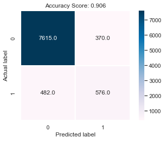

```
Train Accuracy (mean): % 93.34818964907879
std: % 9.239197653008924
MAE (mean): % -0.06651810350921208


Mean Absolute Error (MAE): 0.09
Mean Squared Error (MSE): 0.09
Root Mean Squared Error (RMSE): 0.31


Cohen Score 0.5220578401229347
Matthew Score 0.5230912776740192
```

```python
from xgboost import XGBClassifier
xgb = XGBClassifier()
xgb.fit(X_balanced, y_balanced)

y_pred = xgb.predict(X_test)

print("Decision Tree Algorithm")
print("Classification Report")
print(classification_report(y_test, y_pred))

print("Confusion Matrix","\n")
score = round(accuracy_score(y_test, y_pred),3)
cm1 = confusion_matrix(y_test, y_pred)
sns.heatmap(cm1, annot=True, fmt=".1f", linewidths=.3,
        square = True, cmap = 'PuBu')
plt.ylabel('Actual label')
plt.xlabel('Predicted label')
plt.title('Accuracy Score: {0}'.format(score), size = 12)
plt.show()
print("\n")

accuracies_xgb = cross_val_score(estimator = xgb, X = X_balanced, y = y_balanced, cv = 10)
print("Train Accuracy (mean): %",accuracies_xgb.mean()*100)
print("std: %",accuracies_xgb.std()*100)

scores_xgb = cross_val_score(xgb, X_balanced, y_balanced, scoring='neg_mean_absolute_error', cv=10,)
print ("MAE (mean): %" , scores_xgb.mean())
print("\n")

mae_xgb = mean_absolute_error(xgb.predict(X_test), y_test)
mse_xgb = mean_squared_error(xgb.predict(X_test), y_test)
rmse_xgb = np.sqrt(mse_xgb)
print('Mean Absolute Error (MAE): %.2f' % mae_xgb)
print('Mean Squared Error (MSE): %.2f' % mse_xgb)
print('Root Mean Squared Error (RMSE): %.2f' % rmse_xgb)
print("\n")

print("Cohen Score",cohen_kappa_score(y_test, y_pred))
print("Matthew Score",matthews_corrcoef(y_test, y_pred))

recall_xgb = metrics.recall_score(y_test, y_pred)
precision_xgb = metrics.precision_score(y_test, y_pred)
accuracy_xgb = score
```

## 4. Model Evaluation

### ROC Curves

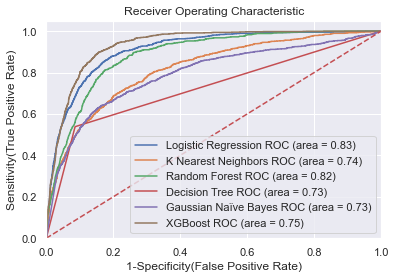

```python
from sklearn.metrics import roc_auc_score, roc_curve
plt.figure()
models_dict = [
    {'label': 'Logistic Regression',
    'model': lr},
    {'label': 'K Nearest Neighbors',
    'model': classifier},
    {'label': 'Random Forest',
    'model': rf},
    {'label': 'Decision Tree',
    'model': dt},
    {'label': 'Gaussian Naïve Bayes',
    'model': gaussiannb},
    {'label': 'XGBoost',
    'model': xgb}
]

for m in models_dict:
    auc = roc_auc_score(y_test, m['model'].predict(X_test))
    fpr, tpr, thresholds = roc_curve(y_test, m['model'].predict_proba(X_test)[:,1])
    plt.plot(fpr, tpr, label='%s ROC (area = %0.2f)' % (m['label'], auc))

plt.plot([0, 1], [0, 1],'r--')
plt.xlim([0.0, 1.0])
plt.ylim([0.0, 1.05])
plt.xlabel('1-Specificity(False Positive Rate)')
plt.ylabel('Sensitivity(True Positive Rate)')
plt.title('Receiver Operating Characteristic')
plt.legend(loc="lower right")
plt.show()
```

## Table of the result

```python
models = ["Logistic Regression", "K Nearest Neighbors", "Random Forest", "Decision Tree", "SVC", "Gaussian Naïve Bayes", "XGBoost"]
recalls = [recall_lr, recall_knn, recall_rf, recall_dt, recall_svc, recall_gnb, recall_xgb]
precisions = [precision_lr, precision_knn, precision_rf, precision_dt, precision_svc, precision_gnb, precision_xgb]
accuracies = [accuracy_lr, accuracy_knn, accuracy_rf, accuracy_dt, accuracy_svc, accuracy_gnb, accuracy_xgb]
MAE = [mae_lr, mae_knn, mae_rf, mae_dt, mae_svc, mae_gnb, mae_xgb]
MSE = [mse_lr, mse_knn, mse_rf, mse_dt, mse_svc, mse_gnb, mse_xgb]
RMSE = [rmse_lr, rmse_knn, rmse_rf, rmse_dt, rmse_svc, rmse_gnb, rmse_xgb]
chart = [recalls, precisions, accuracies, MAE, MSE, RMSE]
chart = pd.DataFrame(chart, columns = models)
chart = chart.set_index(pd.Index(['Recalls', 'Percision','Test Accuracy', 'Mean Absolute Error (MAE)', 'Mean Squared Error (MSE)','Root Mean Squared Error (RMSE)']))
pd.DataFrame.transpose(chart)
```

|  | Recalls | Percision | Test Accuracy | Mean Absolute Error (MAE) | Mean Squared Error (MSE) | Root Mean Squared Error (RMSE) |
| --- | --- | --- | --- | --- | --- | --- |
| Logistic Regression | 0.804348 | 0.433520 | 0.854 | 0.145859 | 0.145859 | 0.381914 |
| K Nearest Neighbors | 0.662571 | 0.317195 | 0.794 | 0.206347 | 0.206347 | 0.454255 |
| Random Forest | 0.662571 | 0.317195 | 0.827 | 0.172841 | 0.172841 | 0.415741 |
| Decision Tree | 0.538752 | 0.453100 | 0.870 | 0.130045 | 0.130045 | 0.360618 |
| SVC | 0.587902 | 0.159569 | 0.590 | 0.410483 | 0.410483 | 0.640690 |
| Gaussian Naïve Bayes | 0.653119 | 0.320650 | 0.798 | 0.202477 | 0.202477 | 0.449975 |
| XGBoost | 0.544423 | 0.608879 | 0.906 | 0.094217 | 0.094217 | 0.306947 |

- Accuracy: overall performance of the model
- Precision: how much positive records we predicted correctly
- Recall: out of actual positive records, how much of them are classified as positive
- F1 score: mixture of precision and recall

## Important Features

```python
# Feature selection
# RFE
from sklearn.feature_selection import RFE

rfe = RFE(lr, n_features_to_select=10)
rfe=rfe.fit(X_balanced,y_balanced)
print("Feature Selection","\n")
print("Important Features:", X_balanced[X_balanced.columns[rfe.ranking_==1].values].columns,"\n")
```

```
Feature Selection

Important Features: Index(['balance', 'duration', 'campaign', 'previous', 'loan_yes',
       'contact_unknown', 'month_mar', 'month_oct', 'month_sep',
       'poutcome_success'],
      dtype='object')
```